# Websérie Reclame aqui com Ciência de Dados | Episódio #2

luisotavio.pro

05/03/2021

(esse material complementar foi 100% produzido usando a linguagem R)

# Como analisar os dados, criar gráficos e análise de texto com a linguagem R | Reclame Aqui com Ciência de Dados #2

Esse é um material complementar, ou seja, não substitui você assistir ao Episódio #2.

[**Clique aqui para assistir o Episódio 2 da Websérie**](https://youtu.be/21T9J23R1T0)

OBJETIVO DO EPISÓDIO #2

- COMPARAR OS RESULTADOS DAS EMPRESAS
- AVALIAR PONTOS FORTES E PONTOS FRACOS DE CADA EMPRESA
- AVALIAR POSSÍVEL RELAÇÃO ENTRE AS PALAVRAS USADAS PELO CLIENTE NA RECLAMAÇÃO E A SOLUÇÃO (OU NÃO) DO CASO

### 1 - LEITURA DOS CONJUNTOS DE DADOS OBTIDOS POR WEBSCRAPING:

```r
library(readr) # carregar a biblioteca 'readr'
info_basicas <- read_delim("info_basicas.txt",
                           "\t", escape_double = FALSE, trim_ws = TRUE)

info_reclamacoes_avaliadas <- read_delim("info_reclamacoes_avaliadas.txt",
                                         "\t", escape_double = FALSE, trim_ws = TRUE)
```

### 2 - BREVE LIMPEZA DOS CONJUNTOS DE DADOS

Removendo valores duplicados:

```r
info_reclamacoes_avaliadas<-unique(info_reclamacoes_avaliadas)
```

Estrutura dos conjuntos de dados:

```r
str(info_basicas)
```

```
## tibble [5 x 9] (S3: spec_tbl_df/tbl_df/tbl/data.frame)
##  $ empresa          : chr [1:5] "Carrefour -  Loja Online" "Magazine Luiza - Loja Online" "Ponto Frio - Loja Online" "Casas Bahia - Loja Online" ...
##  $ indice_solucao   : chr [1:5] "65.5%" "90.5%" "80.7%" "78.3%" ...
##  $ nao_respondidas  : num [1:5] 1708 2919 413 577 669
##  $ avaliadas        : num [1:5] 4842 31488 2862 8224 9306
##  $ nota             : num [1:5] 5.5 8.3 7.3 7.1 8.5
##  $ nota_consumidor  : num [1:5] 3.56 7.13 5.89 5.49 7.45
##  $ percent_voltariam: chr [1:5] "31.7%" "74.5%" "59.6%" "55%" ...
##  $ qnt_reclamacoes  : num [1:5] 17911 75706 9977 31343 24750
##  $ link_loja        : chr [1:5] "https://www.reclameaqui.com.br/empresa/carrefour-loja-online/" "https://www.reclameaqui.com.br/empresa/magazine-luiza-loja-online/" "https://www.reclameaqui.com.br/empresa/ponto-frio-loja-online/" "https://www.reclameaqui.com.br/empresa/casas-bahia-loja-online/" .…
##  - attr(*, "spec")=
##   .. cols(
##   ..   empresa = col_character(),
##   ..   indice_solucao = col_character(),
##   ..   nao_respondidas = col_double(),
##   ..   avaliadas = col_double(),
##   ..   nota = col_double(),
##   ..   nota_consumidor = col_double(),
##   ..   percent_voltariam = col_character(),
##   ..   qnt_reclamacoes = col_double(),
##   ..   link_loja = col_character()
##   .. )
```

```r
str(info_reclamacoes_avaliadas)
```

```
## tibble [4,973 x 5] (S3: tbl_df/tbl/data.frame)
##  $ empresa          : chr [1:4973] "Carrefour -  Loja Online" "Carrefour -  Loja Online" "Carrefour -  Loja Online" "Carrefour -  Loja Online" ...
##  $ titulo_reclamacao: chr [1:4973] "Refrigerador veio 220v" "Produto com defeito e sem nota fiscal" "Descaso!" "não respondem o protocolo de troca a dias" ...
##  $ status_reclamacao: chr [1:4973] "Não Resolvido" "Resolvido" "Não Resolvido" "Não Resolvido" ...
##  $ local_reclamacao : chr [1:4973] "Duque de Caxias" "Tubarão" "Belo Horizonte" "Votuporanga" ...
##  $ tempo_reclamacao : chr [1:4973] "Há 2 meses" "Há 2 meses" "Há 2 meses" "Há 2 meses" ...
```

Acima podemos ver que algumas variáveis numéricas estão como `character`. Isso aconteceu porque estão com o símbolo de %.

A função `gsub` localiza um texto padrão e o substitui pelo texto definido.

Iremos substituir qualquer sinal de % por vazio.

```r
info_basicas$indice_solucao <- gsub("[\\%,]", "", info_basicas$indice_solucao)

info_basicas$percent_voltariam <- gsub("[\\%,]", "",info_basicas$percent_voltariam)
```

Agora podemos transformar a variável da classe texto em numérica.

```r
info_basicas$indice_solucao<- as.numeric(info_basicas$indice_solucao)
info_basicas$percent_voltariam<- as.numeric(info_basicas$percent_voltariam)
```

Estrutura dos dados `info_reclamacoes_avaliadas`:

```r
str(info_reclamacoes_avaliadas)
```

```
## tibble [4,973 x 5] (S3: tbl_df/tbl/data.frame)
##  $ empresa          : chr [1:4973] "Carrefour -  Loja Online" "Carrefour -  Loja Online" "Carrefour -  Loja Online" "Carrefour -  Loja Online" ...
##  $ titulo_reclamacao: chr [1:4973] "Refrigerador veio 220v" "Produto com defeito e sem nota fiscal" "Descaso!" "não respondem o protocolo de troca a dias" ...
##  $ status_reclamacao: chr [1:4973] "Não Resolvido" "Resolvido" "Não Resolvido" "Não Resolvido" ...
##  $ local_reclamacao : chr [1:4973] "Duque de Caxias" "Tubarão" "Belo Horizonte" "Votuporanga" ...
##  $ tempo_reclamacao : chr [1:4973] "Há 2 meses" "Há 2 meses" "Há 2 meses" "Há 2 meses" ...
```

```r
head(info_reclamacoes_avaliadas)
```

```
## # A tibble: 6 x 5
##   empresa   titulo_reclamacao status_reclamac~ local_reclamacao tempo_reclamacao
##   <chr>     <chr>             <chr>            <chr>            <chr>
## 1 Carrefou~ Refrigerador vei~ Não Resolvido    Duque de Caxias  Há 2 meses
## 2 Carrefou~ Produto com defe~ Resolvido        Tubarão          Há 2 meses
## 3 Carrefou~ Descaso!          Não Resolvido    Belo Horizonte   Há 2 meses
## 4 Carrefou~ não respondem o ~ Não Resolvido    Votuporanga      Há 2 meses
## 5 Carrefou~ Estorno de compra Resolvido        Patrocínio       Há 2 meses
## 6 Carrefou~ Estou sendo [Edi~ Não Resolvido    São Paulo        Há 2 meses
```

Precisamos transformar a variável ‘tempo_reclamacao’ para numérica.

Dificuldade: temos respostas em minutos, horas, dias e meses.

Solução: criei uma função `ifelse`.

Iremos avaliar se cada linha do conjunto tem o texto ‘horas’ ou ‘hora’ para a variável ‘tempo_reclamacao’.

Caso seja verdadeiro, iremos extrair apenas os números e multiplicar por 60. Assim deixaremos todos os valores em **minutos**.

Caso seja falso, ou seja, iremos verificar se o tempo está em minutos e, em caso positivo, apenas extraímos os valores (que já estarão na medida que desejamos).

Caso seja falso novamente, iremos verificar se o tempo está em “mês” ou “meses”. Se sim, iremos multiplicar o número por 30x24x60, transformando assim para minutos.

E, caso nenhum teste acima seja VERDADEIRO, só resta a opção do tempo estar em “dia” ou “dias”. Neste caso iremos multiplicar o valor numérico por 60*24 para transformá-lo em minutos.

**O resultado foi armazenado em uma nova coluna, chamada ‘minutos’.**

```r
info_reclamacoes_avaliadas$minutos<-
  ifelse(
    grepl(pattern = paste(c("horas","hora"),collapse = "|"), x = info_reclamacoes_avaliadas$tempo_reclamacao),
    #se o valor tiver em horas (ou hora) irá transformar para minutos.
    #busca apenas os números da coluna 'tempo_reclamacao' e multiplica por 60.
    parse_number(info_reclamacoes_avaliadas$tempo_reclamacao)*60,
    ##### VERIFICAR SE ESTÁ EM MESES, DIA OU MINUTOS
    ifelse(
      grepl(pattern = paste(c("minuto","minutos"),collapse = "|"), x = info_reclamacoes_avaliadas$tempo_reclamacao),
      #busca apenas os números da coluna 'tempo_reclamacao'
      parse_number(info_reclamacoes_avaliadas$tempo_reclamacao),
      ifelse(
        grepl(pattern = paste(c("mês","meses"),collapse = "|"), x = info_reclamacoes_avaliadas$tempo_reclamacao),
        #se o valor tiver em meses (ou mês) irá transformar para minutos.
        #busca apenas os números da coluna 'tempo_reclamacao' e multiplica por 60*24*30.
        parse_number(info_reclamacoes_avaliadas$tempo_reclamacao)*24*60*30,
        #se o valor tiver em dias (ou dia) irá transformar para minutos.
        #busca apenas os números da coluna 'tempo_reclamacao' e multiplica por 60*24.
        parse_number(info_reclamacoes_avaliadas$tempo_reclamacao)*24*60
      )
    )
  )
```

Texto ocultado pelo Reclame Aqui:

Algumas reclamações tem o texto “[Editado pelo Reclame Aqui]” quando o texto original viola as regras do site e precisa ser ocultado.

Iremos substituir todo esse texto por “editado_RA”. Assim essa parte do texto não irá nos atrapalhar em nossa análise.

```r
info_reclamacoes_avaliadas$titulo_reclamacao<-
  gsub('Editado pelo Reclame Aqui','editado_RA',info_reclamacoes_avaliadas$titulo_reclamacao)
```

Cabeçalho dos conjuntos de dados após limpeza e manipulação:

```r
head(info_basicas)
```

```
## # A tibble: 5 x 9
##   empresa indice_solucao nao_respondidas avaliadas  nota nota_consumidor
##   <chr>            <dbl>           <dbl>     <dbl> <dbl>           <dbl>
## 1 Carref~           65.5            1708      4842   5.5            3.56
## 2 Magazi~           90.5            2919     31488   8.3            7.13
## 3 Ponto ~           80.7             413      2862   7.3            5.89
## 4 Casas ~           78.3             577      8224   7.1            5.49
## 5 americ~           90.3             669      9306   8.5            7.45
## # ... with 3 more variables: percent_voltariam <dbl>, qnt_reclamacoes <dbl>,
## #   link_loja <chr>
```

```r
head(info_reclamacoes_avaliadas)
```

```
## # A tibble: 6 x 6
##   empresa titulo_reclamac~ status_reclamac~ local_reclamacao tempo_reclamacao
##   <chr>   <chr>            <chr>            <chr>            <chr>
## 1 Carref~ Refrigerador ve~ Não Resolvido    Duque de Caxias  Há 2 meses
## 2 Carref~ Produto com def~ Resolvido        Tubarão          Há 2 meses
## 3 Carref~ Descaso!         Não Resolvido    Belo Horizonte   Há 2 meses
## 4 Carref~ não respondem o~ Não Resolvido    Votuporanga      Há 2 meses
## 5 Carref~ Estorno de comp~ Resolvido        Patrocínio       Há 2 meses
## 6 Carref~ Estou sendo [ed~ Não Resolvido    São Paulo        Há 2 meses
## # ... with 1 more variable: minutos <dbl>
```

### 3 - COMPARAÇÃO GRÁFICA ENTRE AS DAS EMPRESAS

Carregar bibliotecas:

```r
library(plyr)
library(dplyr)
library(magrittr)
library(ggplot2)
```

Gráficos comparativos usando a biblioteca `ggplot2`

Definindo o tema do gráfico - irá tirar o fundo cinza tradicional dos gráficos ggplot:

```r
theme_set(theme_classic())
```

Comparando as empresas para o quesito: **Índice de Solução (%)**:

Os gráficos da biblioteca `ggplot` são compostos por 3 itens:

1 - O conjunto de dados

2 - Um sistema de coordenadas

3 - As marcas de representação visual (linhas, colunas, pontos, etc)

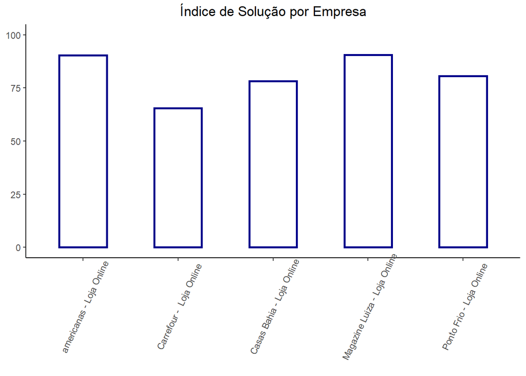

```r
# conjunto de dados + sistema de coordenadas
ggplot(info_basicas, aes(empresa, indice_solucao)) +
# Marcas de representação visual = colunas
geom_col(width = 0.5,size = 1, color="darkblue", fill = "white") +
  #Título do Gráfico
  labs(title="Índice de Solução por Empresa") +
  #Inclinar valores do eixo x (empresas)
  theme(axis.text.x = element_text(angle=65, vjust=0.6),
        #Centralizar o título
        plot.title = element_text(hjust = 0.5),
        #Tirar o título do eixo x
        axis.title.x=element_blank(),
        # Tirar o título do eixo y
        axis.title.y=element_blank())+
  # Definir que o eixo y começa no 0 e termina no 100
  ylim(limits = c(0,100))
```

Comparando as empresas para o quesito: **% de reclamações não respondidas**

Cálculo do percentual de reclamações não respondidas:

```r
info_basicas$per_nao_respondidas<- round(info_basicas$nao_respondidas/info_basicas$qnt_reclamacoes,3)*100
```

Construção do gráfico:

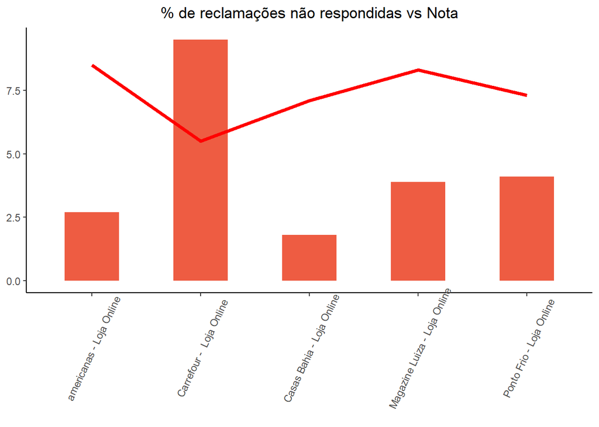

```r
# conjunto de dados + sistema de coordenadas
ggplot(info_basicas, aes(empresa, per_nao_respondidas)) + # Marcas de representação visual = barras
geom_bar(stat="identity", width = 0.5, fill="tomato2") +
  # Título do gráfico
  labs(title="% de reclamações não respondidas vs Nota") +
  # Inclinar valores do eixo x (empresas)
  theme(axis.text.x = element_text(angle=65, vjust=0.6),
        # Centralizar o título
        plot.title = element_text(hjust = 0.5),
        #Tirar o título do eixo x
        axis.title.x=element_blank(),
        #Tirar o título do eixo y
        axis.title.y=element_blank())+
  # Adicionando a nota
  geom_line(aes(x = empresa, y = nota), size = 1.5, color="red", group = 1)
```

Comparando as empresas para o quesito: **Quantidade de reclamações avaliadas**:

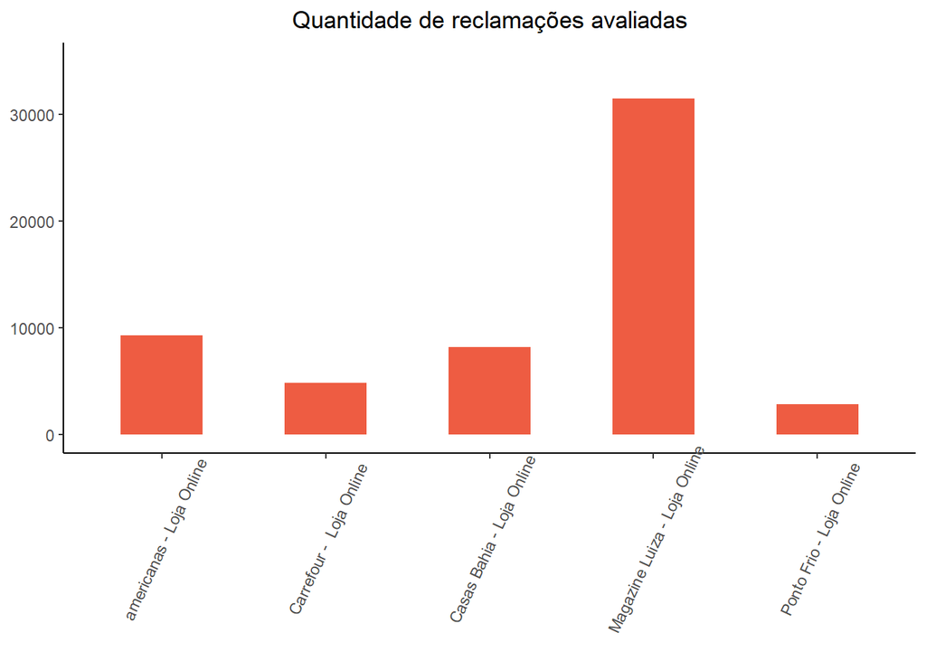

```r
# conjunto de dados + sistema de coordenadas
ggplot(info_basicas, aes(empresa, avaliadas)) +
# Marcas de representação visual = barras
  geom_bar(stat="identity", width = 0.5, fill="tomato2") +
  # Título do gráfico
  labs(title="Quantidade de reclamações avaliadas") +
  # Inclinar valores do eixo x (empresas)
  theme(axis.text.x = element_text(angle=65, vjust=0.6),
        # Centralizar o título
        plot.title = element_text(hjust = 0.5),
        #Tirar o título do eixo x
        axis.title.x=element_blank(),
        #Tirar o título do eixo y
        axis.title.y=element_blank())+
  # Definir que o eixo y começa no 0 e termina no 35000
  ylim(limits = c(0,35000))
```

Comparando as empresas para o quesito: **Nota do Consumidor**

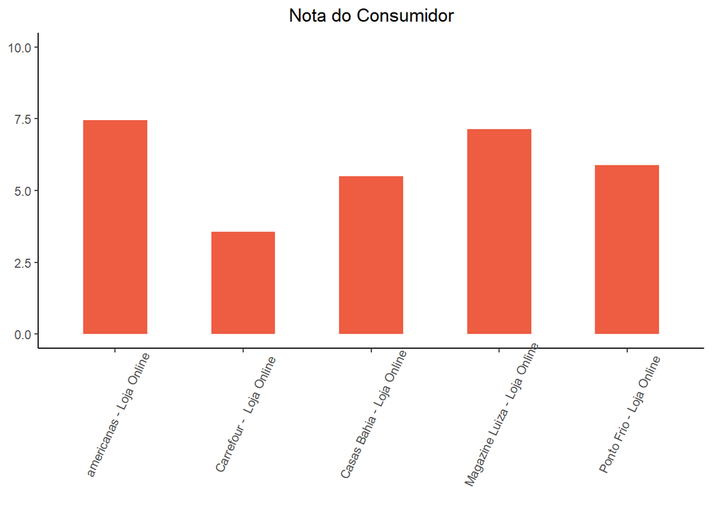

```r
# conjunto de dados + sistema de coordenadas
ggplot(info_basicas, aes(empresa, nota_consumidor)) +
# Marcas de representação visual = barras
geom_bar(stat="identity", width = 0.5, fill="tomato2") +
  # Título do gráfico
  labs(title="Nota do Consumidor") +
  # Inclinar valores do eixo x (empresas)
  theme(axis.text.x = element_text(angle=65, vjust=0.6),
        # Centralizar o título
        plot.title = element_text(hjust = 0.5),
        #Tirar o título do eixo x
        axis.title.x=element_blank(),
        #Tirar o título do eixo y
        axis.title.y=element_blank())+
  # Definir que o eixo y começa no 0 e termina no 10
  ylim(limits = c(0,10))
```

Análise de há quanto tempo foram feitas as últimas reclamações:

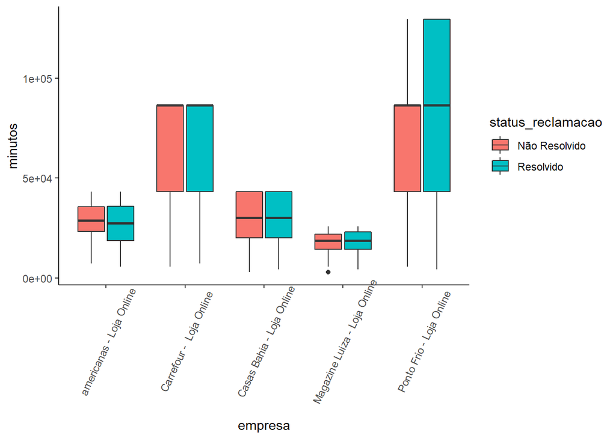

```r
# eixo x = empresa
# eixo y = minutos
# colorir pela variável 'status_reclamacao'
ggplot(info_reclamacoes_avaliadas, aes(x=empresa, y=minutos, fill=status_reclamacao)) +
  # Representação visual = boxplot
  geom_boxplot() +
  # Inclinar valores do eixo x (empresas)
  theme(axis.text.x = element_text(angle=65, vjust=0.6))
```

### 4 - MINERAÇÃO DE TEXTO - ANÁLISE DAS RECLAMAÇÕES

Bibliotecas que iremos utilizar:

```r
library(tm)
library(wordcloud2)
library(tidytext)
```

Vamos separar todas as palavras que estão no título da reclamação. Então, para saber a qual título elas pertencem, vamos criar um id para cada título das reclamações:

```r
info_reclamacoes_avaliadas %<>% mutate(reclamacao_id = row_number())
```

Criar uma linha para cada palavra do título:

```r
avaliadas_token<-info_reclamacoes_avaliadas %>%
  select(titulo_reclamacao,reclamacao_id) %>%
  unnest_tokens(word,titulo_reclamacao)
```

Stopwords são palavras neutras, que não nos ajudam em nada para analisar a reclamação do consumidor. São por exemplo as preposições.

A função `stopwords` nos retorna vários exemplos de stopwords.

Remover stopwords:

```r
stop_words_pt<-data.frame(word=(stopwords(kind = "pt")))
avaliadas_token <- avaliadas_token %>%
  anti_join(stop_words_pt)
```

Remover palavras com duas letras, pois provavelmente também serão palavras inúteis:

```r
avaliadas_token %<>%
  filter(sapply(avaliadas_token$word,nchar)>2)
```

#### HÁ RELAÇÃO ENTRE AS PALAVRAS DO TÍTULO E A SOLUÇÃO DA RECLAMAÇÃO?

O que queremos saber aqui é se a chance da empresa solucionar o problema está relacionada às palavras escritas no título da reclamação.

```r
#juntar o status da reclamação no conjunto de dados com as palavras

avaliadas_token <-join(avaliadas_token,
info_reclamacoes_avaliadas[,c("reclamacao_id","status_reclamacao")])

analise_palavras<-avaliadas_token %>%
  group_by(word) %>%
  mutate(percentual_solucao = sum(status_reclamacao=="Resolvido")/n(),
         qnt_palavra = n()) %>%
  select(word,percentual_solucao,qnt_palavra) %>%
  unique()%>%
  ungroup()

#filtrar apenas os resultados com frequencia maior que 50
analise_palavras %<>% filter(qnt_palavra >50)
```

E se a gente separar por empresa?

```r
avaliadas_token_empresa <- join(avaliadas_token,
info_reclamacoes_avaliadas[,c("reclamacao_id","empresa")])
```

Percentual geral de solução por empresa sem considerar as palavras do título

```r
analise_empresas <-avaliadas_token_empresa %>%
  group_by(empresa) %>%
  mutate(percentual_solucao = sum(status_reclamacao=="Resolvido")/n()) %>%
  select(percentual_solucao,empresa) %>%
  unique() %>%
  ungroup()
```

Percentual geral de solução por empresa por palavras no título

```r
analise_palavras_empresas <-avaliadas_token_empresa %>%
  group_by(word,empresa) %>%
  mutate(percentual_solucao = sum(status_reclamacao=="Resolvido")/n(),
         qnt_palavra = n()) %>%
  select(word,percentual_solucao,qnt_palavra,empresa) %>%
  unique()%>%
  ungroup()
analise_palavras_empresas %<>% filter(qnt_palavra >50)
```

#### CORRELAÇÃO ENTRE PALAVRAS:

QUAIS AS PALAVRAS QUE MAIS APARECERAM JUNTAS?

```r
library(widyr)
library(igraph)
library(ggraph)
```

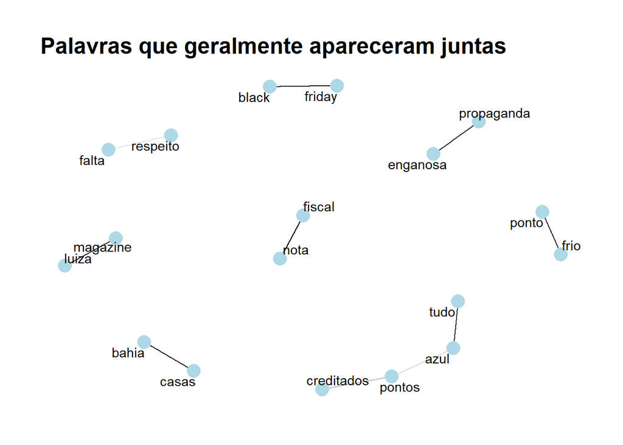

```r
correlacao <- avaliadas_token %>%
  group_by(word) %>%
  filter(n() > 20) %>%
  pairwise_cor(word, reclamacao_id, sort = TRUE,upper=F)%>%
  ungroup()
correlacao %<>% filter(correlation >0.3)
correlacao %>%
  arrange(-correlation) %>%
  top_n(10) %>% #Filtrar as 10 maiores
  graph_from_data_frame() %>%
  ggraph(layout = 'fr') +
  guides(edge_alpha = "none", edge_width = "none") +
  scale_edge_colour_gradientn(limits = c(-1, 1), colors = c("firebrick2", "dodgerblue2")) +
  geom_edge_link(aes(edge_alpha = correlation), show.legend = FALSE) +
  geom_node_point(color = 'lightblue', size = 5) +
  geom_node_text(aes(label = name), repel = TRUE) +
  theme_graph() +
  labs(title = "Palavras que geralmente apareceram juntas")
```

#### Palavras que mais aparecem:

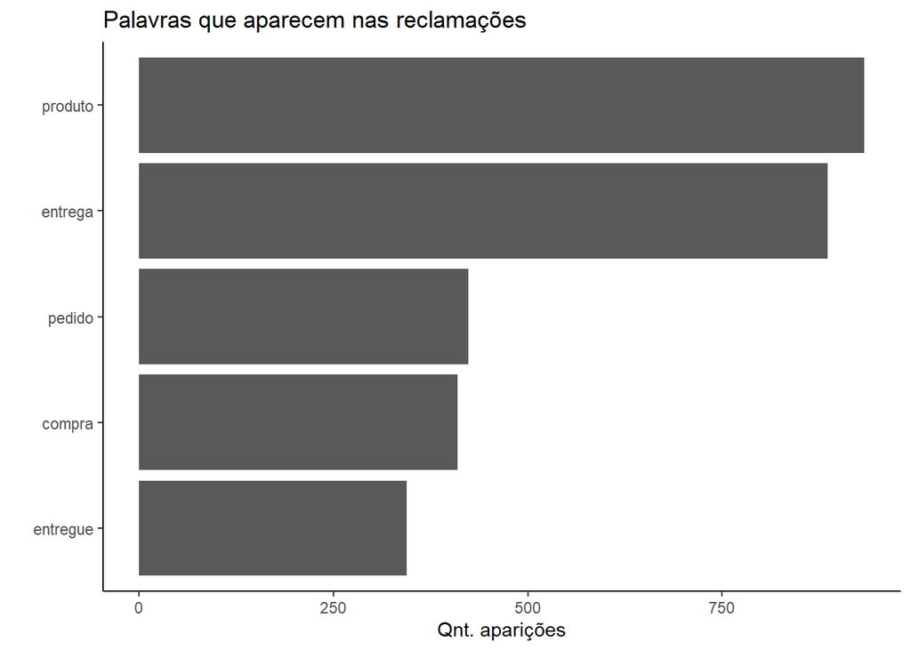

```r
dados_grafico<- avaliadas_token %>% count(word, sort = T) %>% top_n(5) %>%
  mutate(word = reorder(word,n))

  ggplot(dados_grafico,aes(x = word, y=n)) +
  geom_col() +
  xlab(NULL) +
  coord_flip() +
  theme_classic() +
  labs(x = "",
       y = "Qnt. aparições",
       title = paste0("Palavras que aparecem nas reclamações"))
```

#### NUVEM DE PALAVRAS

Esse é o gráfico ‘wordcloud’

```r
library(wordcloud2)
  wordcloud_dados <- analise_palavras %>%
    select(word,qnt_palavra) %>%
    rename(freq = qnt_palavra)

  wordcloud2(data = wordcloud_dados)
```

[interactive chart not shown]

### 5 Repositório no Github

Todos os arquivos utilizados na Websérie Reclame Aqui com Ciência de Dados + Conjuntos de dados ficarão disponíveis no Github.

[Para acessar, clique aqui.](https://github.com/luisotavio88/webserie_reclameaqui)